# Predicting Diabetes from Demographics and Body Measures (NHANES 2017–March 2020)

### DATA602 Semester Project (Final)

**Course:** DATA602 – Principles of Data Science

**Instructor:** Dr. Fardina Fathmiul Alam

**Group Members:** Safa Malik, Ayesha Khan

- Introduction
- Notebook Setup
- Data Preprocessing and Data Cleaning
  - A. Demographics Data
  - B. Diabetes Questionnaire Data
  - C. Body Examination (BMI) Data-Data)
  - Joining the Data
  - Missing Values
  - Check for Duplicates in the Primary Key Column
- Exploratory Data Analysis
  - Statistical Summary of the dataset
  - Distribution of Features
  - Variance, covariance, and correlation of the dataset
  - 1. Kruskal-Wallis test for Age and Diabetes
  - 2. Correlation: BMI vs Waist
  - 3. Chi-Squared Test: Race and Diabetes
- Machine Learning Models
  - Create 3-Class Target Variable
  - Choose features
  - 1. Logistic Regression
    - Train-Test Split
    - Imputing and standardizing features
    - Train Multinomial Logistic Regression
    - Evaluate Logistic Regression Performance
  - 2. Random Forest
    - Evaluate Random Forest Performance
    - Feature Importance
  - 3. XGBoost
    - Evaluate XGBoost Performance
  - Testing Improvements: Increasing class weights for minority classes
    - Evaluate XGBoost (Class Weights) Performance
  - 4. Focal Loss Neural Network
    - Evaluate Focal Loss NN Performance
- Results Summary and Model Comparison
- Conclusion
- References and Further Reading

## Introduction

Diabetes is a major public-health concern, and early identification can help guide timely follow-up and lifestyle interventions. In this course project, we build **multi-class classification** models to predict diabetes status using publicly available data from the CDC’s **National Health and Nutrition Examination Survey (NHANES)**.

### Data sources (NHANES 2017 - March 2020 pre-pandemic)

- **Demographics (P_DEMO):** https://wwwn.cdc.gov/Nchs/Data/Nhanes/Public/2017/DataFiles/P_DEMO.htm
- **Diabetes Questionnaire (P_DIQ):** https://wwwn.cdc.gov/Nchs/Data/Nhanes/Public/2017/DataFiles/P_DIQ.htm
- **Body Measures (P_BMX / BMX):** https://wwwn.cdc.gov/Nchs/Data/Nhanes/Public/2017/DataFiles/P_BMX.htm

### Target label (3 classes)

We derive a 3-class outcome from the questionnaire fields:

- **Diabetic:** respondent reports being diagnosed with diabetes.
- **Prediabetic:** respondent reports being told they have prediabetes / borderline diabetes.
- **Not Diabetic:** neither of the above.

### Modeling goal and evaluation

This is framed as a **screening-style** task. We therefore pay special attention to **recall (sensitivity)** for the **Diabetic** class (and secondarily Prediabetic), while still aiming to keep performance strong for Not Diabetic.

### Overview of results

| Model | Accuracy | Diabetic Recall | Prediabetic Recall | Not Diabetic Recall |
| --- | --- | --- | --- | --- |
| Logistic Regression (baseline) | 0.631 | 0.65 | 0.43 | 0.65 |
| **Logistic Regression (adjusted class weights)** | 0.645 | 0.62 | 0.38 | 0.68 |
| XGBoost (baseline) | 0.812 | 0.16 | 0.00 | 0.97 |
| **XGBoost (class weights)** | **0.775** | **0.61** | 0.11 | **0.86** |
| Random Forest | 0.808 | 0.16 | 0.02 | 0.97 |
| **Balanced Random Forest** | 0.645 | 0.48 | **0.58** | 0.61 |
| **Focal Loss Neural Network (thresholded)** | 0.63 | **0.70** | 0.33 | 0.65 |

**Takeaway:** The **class-weighted XGBoost** model provides the best overall trade-off for a screening goal—substantially improving *Diabetic recall* while maintaining strong performance on *Not Diabetic*.

> **Disclaimer:** This notebook is for an academic project and is **not** medical advice or a clinical diagnostic tool.

## Notebook Setup

**Notes for Reproducibility**

- This notebook assumes the NHANES `.XPT` files are downloaded locally (see links in the Introduction) and that the file paths below point to the local copies.
- Random seeds (`random_state`) are set in the train/test split and models to make results more reproducible.
- Main Python packages used: `pandas`, `numpy`, `matplotlib/seaborn`, `scikit-learn`, and `xgboost`.

**NHANES survey design note (important limitations):** NHANES is a complex, weighted survey. For nationally representative inference, analyses typically incorporate **sample weights, strata, and PSU**. This project focuses on predictive modeling rather than weighted estimation; see the NHANES weighting tutorial for guidance: https://wwwn.cdc.gov/nchs/nhanes/tutorials/weighting.aspx

```python
# Import necessary libraries
import pandas as pd
import numpy as np
import seaborn as sns
import matplotlib.pyplot as plt
import seaborn as sns
from scipy import stats
import statsmodels.formula.api as smf
from scipy.stats import chi2_contingency
import matplotlib.ticker as mtick
from scipy.stats import kruskal
from sklearn.model_selection import train_test_split
from sklearn.compose import ColumnTransformer
from sklearn.pipeline import Pipeline
from sklearn.impute import SimpleImputer
from sklearn.preprocessing import OneHotEncoder, StandardScaler
from sklearn.linear_model import LogisticRegression
from sklearn.metrics import (accuracy_score,classification_report,confusion_matrix)
from sklearn.ensemble import RandomForestClassifier
from sklearn.preprocessing import LabelEncoder
from xgboost import XGBClassifier
```

## Data Preprocessing and Data Cleaning

### A. Demographics Data

- Data Download Link: https://wwwn.cdc.gov/nchs/nhanes/search/datapage.aspx?Component=Demographics
- Documentation: https://wwwn.cdc.gov/Nchs/Data/Nhanes/Public/2017/DataFiles/P_DEMO.htm

```python
# Load Demographics Data 2017-2020 from NHANES
df_dem = pd.read_sas('P_DEMO.xpt', format='xport')
```

```python
# Look at the first few records
print(f'shape: {df_dem.shape}')
df_dem.head()
```

```
shape: (15560, 29)
```

|  | SEQN | SDDSRVYR | RIDSTATR | RIAGENDR | RIDAGEYR | RIDAGEMN | RIDRETH1 | RIDRETH3 | RIDEXMON | DMDBORN4 | ... | FIAINTRP | MIALANG | MIAPROXY | MIAINTRP | AIALANGA | WTINTPRP | WTMECPRP | SDMVPSU | SDMVSTRA | INDFMPIR |
| --- | --- | --- | --- | --- | --- | --- | --- | --- | --- | --- | --- | --- | --- | --- | --- | --- | --- | --- | --- | --- | --- |
| 0 | 109263.0 | 66.0 | 2.0 | 1.0 | 2.0 | NaN | 5.0 | 6.0 | 2.0 | 1.0 | ... | 2.0 | NaN | NaN | NaN | NaN | 7891.762435 | 8.951816e+03 | 3.0 | 156.0 | 4.66 |
| 1 | 109264.0 | 66.0 | 2.0 | 2.0 | 13.0 | NaN | 1.0 | 1.0 | 2.0 | 1.0 | ... | 2.0 | 1.0 | 2.0 | 2.0 | 1.0 | 11689.747264 | 1.227116e+04 | 1.0 | 155.0 | 0.83 |
| 2 | 109265.0 | 66.0 | 2.0 | 1.0 | 2.0 | NaN | 3.0 | 3.0 | 2.0 | 1.0 | ... | 2.0 | NaN | NaN | NaN | NaN | 16273.825939 | 1.665876e+04 | 1.0 | 157.0 | 3.06 |
| 3 | 109266.0 | 66.0 | 2.0 | 2.0 | 29.0 | NaN | 5.0 | 6.0 | 2.0 | 2.0 | ... | 2.0 | 1.0 | 2.0 | 2.0 | 1.0 | 7825.646112 | 8.154968e+03 | 2.0 | 168.0 | 5.00 |
| 4 | 109267.0 | 66.0 | 1.0 | 2.0 | 21.0 | NaN | 2.0 | 2.0 | NaN | 2.0 | ... | 2.0 | NaN | NaN | NaN | NaN | 26379.991724 | 5.397605e-79 | 1.0 | 156.0 | 5.00 |

5 rows × 29 columns

#### Preparing Column Names

We notice that the column names are 'coded' and not very intuitive. So we leveraged the [data documentation](https://wwwn.cdc.gov/Nchs/Data/Nhanes/Public/2017/DataFiles/P_DEMO.htm) to:

1. Keep only the required columns
2. Rename the column names so they are more intuitive

```python
# Only keep required columns
columns_to_keep = ['SEQN', 'RIAGENDR', 'RIDAGEYR', 'RIDRETH3', 'DMDBORN4', 'DMDMARTZ', 'RIDEXPRG', 'DMDYRUSZ', 'DMDEDUC2', 'INDFMPIR']
df_dem = df_dem[columns_to_keep]
```

```python
# Rename the columns so they are more understandable
df_dem.rename(columns={
    'SEQN': 'Sequence_Number',
    'RIAGENDR': 'Gender',
    'RIDAGEYR': 'Age',
    'RIDRETH3': 'Race',
    'DMDBORN4': 'Country_Birth',
    'DMDMARTZ': 'Marital_Status',
    'RIDEXPRG': 'Pregnancy_Status',
    'DMDYRUSZ': 'Time_In_US',
    'DMDEDUC2': 'Education_Level',
    'INDFMPIR': 'FamilyIncome_to_Poverty'
}, inplace=True)
df_dem.head()
```

|  | Sequence_Number | Gender | Age | Race | Country_Birth | Marital_Status | Pregnancy_Status | Time_In_US | Education_Level | FamilyIncome_to_Poverty |
| --- | --- | --- | --- | --- | --- | --- | --- | --- | --- | --- |
| 0 | 109263.0 | 1.0 | 2.0 | 6.0 | 1.0 | NaN | NaN | NaN | NaN | 4.66 |
| 1 | 109264.0 | 2.0 | 13.0 | 1.0 | 1.0 | NaN | NaN | NaN | NaN | 0.83 |
| 2 | 109265.0 | 1.0 | 2.0 | 3.0 | 1.0 | NaN | NaN | NaN | NaN | 3.06 |
| 3 | 109266.0 | 2.0 | 29.0 | 6.0 | 2.0 | 3.0 | 2.0 | 2.0 | 5.0 | 5.00 |
| 4 | 109267.0 | 2.0 | 21.0 | 2.0 | 2.0 | 3.0 | 3.0 | 3.0 | 4.0 | 5.00 |

#### Handling categorical fields with codes:

- Gender (RIAGENDR): 1=Male, 2=Female.
- Race (RIDRETH3): 1=Mexican American, 2=Other Hispanic, 3=NH White, 4=NH Black, 6=NH Asian, 7=Other/Multiracial (5 unused).
- Country_Birth (DMDBORN4): 1=Born in US, 2=Born elsewhere.
- Time_In_US (DMDYRUSZ) (asked of foreign-born; US-born are NA): 1=<5y, 2=5–<15y, 3=15–<30y, 4=≥30y.
- Education_Level (DMDEDUC2) (only valid for age ≥20): 1=<9th, 2=9–11th (incl. 12th, no diploma), 3=HS/GED, 4=Some college/AA, 5=College+.
- Marital_Status (DMDMARTZ) (released for age ≥20): 1=Married/Living with partner, 2=Widowed/Divorced/Separated, 3=Never married.
- Pregnancy_Status (RIDEXPRG) (released only for women 20–44): 1=Pregnant, 2=Not pregnant, 3=Could not be determined.

```python
# Define the mapping from numeric codes to descriptive strings
gender_map = {1: 'Male', 2: 'Female'}
race_map = {1: 'Mexican American', 2: 'Other Hispanic', 3: 'NH White', 4: 'NH Black', 6: 'NH Asian', 7: 'Other/Multiracial'}
country_map = {1: 'US Born', 2: 'Others', 77: 'RefusedResponse', 99: 'Dont Know'}
marital_map = {1: 'Married/LiveIn', 2: 'Wid/Div/Sep', 3: 'Never Married', 77:'RefusedResoponse', 99: 'Dont Know'}
pregnancy_map = {1: 'Yes', 2: 'No', 3: 'Dont Know'}
ustime_map= {1:'<5y', 2:'5–<15y', 3:'15–<30y', 4:'>=30y', 77:'RefusedResoponse', 99: 'Dont Know'}
edu_map = {1: '<9th', 2: '9–11th', 3: 'HS/GED', 4: 'Some college/AA', 5: 'College+', 77:'RefusedResoponse', 99: 'Dont Know'}



# Use .map() to decode the categorical columns - This overwrites the original columns with the new string values
df_dem['Gender'] = df_dem['Gender'].map(gender_map)
df_dem['Race'] = df_dem['Race'].map(race_map)
df_dem['Country_Birth'] = df_dem['Country_Birth'].map(country_map)
df_dem['Marital_Status'] = df_dem['Marital_Status'].map(marital_map)
df_dem['Pregnancy_Status'] = df_dem['Pregnancy_Status'].map(pregnancy_map)
df_dem['Time_In_US'] = df_dem['Time_In_US'].map(ustime_map)
df_dem['Education_Level'] = df_dem['Education_Level'].map(edu_map)

df_dem
```

|  | Sequence_Number | Gender | Age | Race | Country_Birth | Marital_Status | Pregnancy_Status | Time_In_US | Education_Level | FamilyIncome_to_Poverty |
| --- | --- | --- | --- | --- | --- | --- | --- | --- | --- | --- |
| 0 | 109263.0 | Male | 2.0 | NH Asian | US Born | NaN | NaN | NaN | NaN | 4.66 |
| 1 | 109264.0 | Female | 13.0 | Mexican American | US Born | NaN | NaN | NaN | NaN | 0.83 |
| 2 | 109265.0 | Male | 2.0 | NH White | US Born | NaN | NaN | NaN | NaN | 3.06 |
| 3 | 109266.0 | Female | 29.0 | NH Asian | Others | Never Married | No | 5–<15y | College+ | 5.00 |
| 4 | 109267.0 | Female | 21.0 | Other Hispanic | Others | Never Married | Dont Know | 15–<30y | Some college/AA | 5.00 |
| ... | ... | ... | ... | ... | ... | ... | ... | ... | ... | ... |
| 15555 | 124818.0 | Male | 40.0 | NH Black | US Born | Married/LiveIn | NaN | NaN | College+ | 3.82 |
| 15556 | 124819.0 | Male | 2.0 | NH Black | US Born | NaN | NaN | NaN | NaN | 0.07 |
| 15557 | 124820.0 | Female | 7.0 | NH White | US Born | NaN | NaN | NaN | NaN | 1.22 |
| 15558 | 124821.0 | Male | 63.0 | NH Black | US Born | Wid/Div/Sep | NaN | NaN | 9–11th | 3.71 |
| 15559 | 124822.0 | Male | 74.0 | Other Hispanic | Others | Married/LiveIn | NaN | >=30y | HS/GED | NaN |

15560 rows × 10 columns

### B. Diabetes Questionnaire Data

- Data Download Link: https://wwwn.cdc.gov/nchs/nhanes/search/datapage.aspx?Component=Questionnaire&Cycle=2017-2020
- Documentation: https://wwwn.cdc.gov/Nchs/Data/Nhanes/Public/2017/DataFiles/P_DIQ.htm

```python
# Load Diabetes Data 2017-2020 from NHANES
df_db = pd.read_sas('P_DIQ.xpt', format='xport')
```

```python
df_db.head()
```

|  | SEQN | DIQ010 | DID040 | DIQ160 | DIQ180 | DIQ050 | DID060 | DIQ060U | DIQ070 | DIQ230 | ... | DIQ300D | DID310S | DID310D | DID320 | DID330 | DID341 | DID350 | DIQ350U | DIQ360 | DIQ080 |
| --- | --- | --- | --- | --- | --- | --- | --- | --- | --- | --- | --- | --- | --- | --- | --- | --- | --- | --- | --- | --- | --- |
| 0 | 109263.0 | 2.0 | NaN | NaN | NaN | NaN | NaN | NaN | NaN | NaN | ... | NaN | NaN | NaN | NaN | NaN | NaN | NaN | NaN | NaN | NaN |
| 1 | 109264.0 | 2.0 | NaN | 2.0 | 2.0 | NaN | NaN | NaN | NaN | NaN | ... | NaN | NaN | NaN | NaN | NaN | NaN | NaN | NaN | NaN | NaN |
| 2 | 109265.0 | 2.0 | NaN | NaN | NaN | NaN | NaN | NaN | NaN | NaN | ... | NaN | NaN | NaN | NaN | NaN | NaN | NaN | NaN | NaN | NaN |
| 3 | 109266.0 | 2.0 | NaN | 1.0 | 1.0 | NaN | NaN | NaN | 2.0 | NaN | ... | NaN | NaN | NaN | NaN | NaN | NaN | NaN | NaN | NaN | NaN |
| 4 | 109267.0 | 2.0 | NaN | 2.0 | 2.0 | NaN | NaN | NaN | NaN | NaN | ... | NaN | NaN | NaN | NaN | NaN | NaN | NaN | NaN | NaN | NaN |

5 rows × 28 columns

#### Preparing Column Names

We notice that the column names are 'coded' and not very intuitive. So we leveraged the [data documentation](https://wwwn.cdc.gov/Nchs/Data/Nhanes/Public/2017/DataFiles/P_DEMO.htm) to:

1. Keep only the required columns
2. Rename the column names so they are more intuitive

```python
# Only keep required columns
columns_to_keep = ['SEQN', 'DIQ010', 'DIQ160']
df_db = df_db[columns_to_keep]
```

```python
# Rename the columns so they are more understandable
df_db.rename(columns={
    'SEQN': 'Sequence_Number',
    'DIQ010': 'Dr_Diagnosed_Diab',
    'DIQ160': 'Ever_PreDiab'
}, inplace=True)
df_db.head()
```

|  | Sequence_Number | Dr_Diagnosed_Diab | Ever_PreDiab |
| --- | --- | --- | --- |
| 0 | 109263.0 | 2.0 | NaN |
| 1 | 109264.0 | 2.0 | 2.0 |
| 2 | 109265.0 | 2.0 | NaN |
| 3 | 109266.0 | 2.0 | 1.0 |
| 4 | 109267.0 | 2.0 | 2.0 |

#### Handling categorical fields with codes:

- Dr_Diagnosed_Diab (DIQ010): 1=Yes, 2=No, 3=Borderline, 7= Refused, 8 = Don't Know
- Ever_PreDiab: 1=Yes, 2=No, 7= Refused, 9 = Don't Know

```python
# Define the mapping from numeric codes to descriptive strings
diag_map = {1: 'Yes', 2: 'No', 3: 'Borderline', 7:'Refused', 8: 'Dont Know'}
everdiab_map = {1: 'Yes', 2: 'No', 7:'Refused', 9: 'Dont Know'}


# Use .map() to decode the categorical columns - This overwrites the original columns with the new string values
df_db['Dr_Diagnosed_Diab'] = df_db['Dr_Diagnosed_Diab'].map(diag_map)
df_db['Ever_PreDiab'] = df_db['Ever_PreDiab'].map(everdiab_map)


df_db
```

|  | Sequence_Number | Dr_Diagnosed_Diab | Ever_PreDiab |
| --- | --- | --- | --- |
| 0 | 109263.0 | No | NaN |
| 1 | 109264.0 | No | No |
| 2 | 109265.0 | No | NaN |
| 3 | 109266.0 | No | Yes |
| 4 | 109267.0 | No | No |
| ... | ... | ... | ... |
| 14981 | 124818.0 | No | No |
| 14982 | 124819.0 | No | NaN |
| 14983 | 124820.0 | No | NaN |
| 14984 | 124821.0 | Borderline | NaN |
| 14985 | 124822.0 | No | Yes |

14986 rows × 3 columns

### C. Body Examination (BMI) Data

- Data Download Link: https://wwwn.cdc.gov/nchs/nhanes/search/datapage.aspx?Component=Examination&Cycle=2017-2020
- Documentation: https://wwwn.cdc.gov/Nchs/Data/Nhanes/Public/2017/DataFiles/P_BMX.htm

```python
# Load BMI Data 2017-2020 from NHANES
df_bmi = pd.read_sas('P_BMX.xpt', format='xport')
```

```python
df_bmi.head()
```

|  | SEQN | BMDSTATS | BMXWT | BMIWT | BMXRECUM | BMIRECUM | BMXHEAD | BMIHEAD | BMXHT | BMIHT | ... | BMXLEG | BMILEG | BMXARML | BMIARML | BMXARMC | BMIARMC | BMXWAIST | BMIWAIST | BMXHIP | BMIHIP |
| --- | --- | --- | --- | --- | --- | --- | --- | --- | --- | --- | --- | --- | --- | --- | --- | --- | --- | --- | --- | --- | --- |
| 0 | 109263.0 | 4.0 | NaN | NaN | NaN | NaN | NaN | NaN | NaN | NaN | ... | NaN | NaN | NaN | NaN | NaN | NaN | NaN | NaN | NaN | NaN |
| 1 | 109264.0 | 1.0 | 42.2 | NaN | NaN | NaN | NaN | NaN | 154.7 | NaN | ... | 36.3 | NaN | 33.8 | NaN | 22.7 | NaN | 63.8 | NaN | 85.0 | NaN |
| 2 | 109265.0 | 1.0 | 12.0 | NaN | 91.6 | NaN | NaN | NaN | 89.3 | NaN | ... | NaN | NaN | 18.6 | NaN | 14.8 | NaN | 41.2 | NaN | NaN | NaN |
| 3 | 109266.0 | 1.0 | 97.1 | NaN | NaN | NaN | NaN | NaN | 160.2 | NaN | ... | 40.8 | NaN | 34.7 | NaN | 35.8 | NaN | 117.9 | NaN | 126.1 | NaN |
| 4 | 109269.0 | 3.0 | 13.6 | NaN | 90.9 | NaN | NaN | NaN | NaN | 1.0 | ... | NaN | NaN | NaN | 1.0 | NaN | 1.0 | NaN | 1.0 | NaN | NaN |

5 rows × 22 columns

#### Preparing Column Names

We notice that the column names are 'coded' and not very intuitive. So we leveraged the [data documentation](https://wwwn.cdc.gov/Nchs/Data/Nhanes/Public/2017/DataFiles/P_BMX.htm) to:

1. Keep only the required columns
2. Rename the column names so they are more intuitive

```python
# Only keep required columns
columns_to_keep = ['SEQN', 'BMXBMI', 'BMXWAIST']
df_bmi = df_bmi[columns_to_keep]
```

```python
# Rename the columns so they are more understandable
df_bmi.rename(columns={
    'SEQN': 'Sequence_Number',
    'BMXBMI': 'BMI',
    'BMXWAIST': 'Waist_Circumference'
}, inplace=True)
df_bmi.head()
```

|  | Sequence_Number | BMI | Waist_Circumference |
| --- | --- | --- | --- |
| 0 | 109263.0 | NaN | NaN |
| 1 | 109264.0 | 17.6 | 63.8 |
| 2 | 109265.0 | 15.0 | 41.2 |
| 3 | 109266.0 | 37.8 | 117.9 |
| 4 | 109269.0 | NaN | NaN |

## Joining the Data

#### Using inner join to get all participants that have diabetes data as well as demographics data

**What happens in this step (and why it matters):**

- We merge the Demographics, Diabetes Questionnaire, and Body Measures datasets using the NHANES participant identifier `SEQN` (renamed here as `Sequence_Number`).
- We use an **inner join** so that the final modeling dataset includes only participants who have *all* required information available.
- After merging, we verify the resulting row counts and inspect key columns to confirm the join behaved as expected.

> *Alternative (not used here):* a left join could keep more participants, but would introduce more missingness and may require more advanced imputation strategies.

```python
# Checking data type for the sequence columns in both tables before joining
#print(df_dem['Sequence_Number'].dtype)df_db
#print(df_db['Sequence_Number'].dtype)

# Converting to string
df_dem['Sequence_Number'] = df_dem['Sequence_Number'].astype(str)
df_db['Sequence_Number'] = df_db['Sequence_Number'].astype(str)
df_bmi['Sequence_Number'] = df_bmi['Sequence_Number'].astype(str)
```

```python
df_combined = pd.merge(df_dem, df_db, on='Sequence_Number', how='inner')
df_combined = pd.merge(df_combined, df_bmi, on='Sequence_Number', how='inner')
```

```python
print(f"""Total Records in:
- Demographics Data: {len(df_dem)}
- Diabetes Data: {len(df_db)}
- BMI Data: {len(df_bmi)}
- Combined Data after joining: {len(df_combined)}
""")
```

```
Total Records in:
- Demographics Data: 15560
- Diabetes Data: 14986
- BMI Data: 14300
- Combined Data after joining: 13772
```

## Missing Values

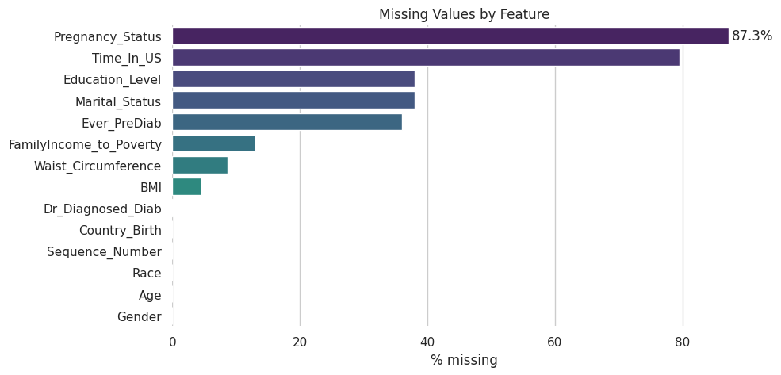

```python
# Plot missing values by column
miss = (df_combined.isna().mean()*100).sort_values(ascending=False)

sns.set_theme(style="whitegrid")
plt.figure(figsize=(10, max(4, 0.35*len(miss))))
ax = sns.barplot(x=miss.values, y=miss.index, palette="viridis")
ax.set(xlabel="% missing", ylabel="", title="Missing Values by Feature")
ax.bar_label(ax.containers[0], fmt="%.1f%%", padding=3)
sns.despine(left=True, bottom=True)
plt.tight_layout(); plt.show()
```

- Very high “missing” for Pregnancy_Status (87%) and Time_In_US (79.5%) are mostly not-applicable:
  - Pregnancy is only asked of females of reproductive age;
  - Time in U.S. is skipped for U.S.-born respondents. We plan to recode these to “Not in universe” instead of treating as true missing.
- Education_Level, Marital_Status, Ever_PreDiab (~36–38% “missing”) are largely skip patterns too (e.g., items not asked of children/teens, or “Refused/Don’t know”).
  - We will analyze these only among age-eligible adults and keep a separate “NIU/skip” category.
- Waist_Circumference (8.7%) and BMI (4.6%) may be due to missed exams or exclusions. We will handle these teo based on the documentation.
- Core demographics (Sequence_Number, Gender, Age, Race, Country_Birth, Dr_Diagnosed_Diab) are essentially complete.

#### Handling missing values

Methodology on Handling Missing Values:

- We will analyze each variable only for people it actually applies to: Mark NIU/skip (not asked) separately from the real missing values.
- We won't do listwise deletion as it will remove lots of kids and US-born adults for no reason.

```python
df = df_combined
NIU = "NIU (not asked)"

# 1. Define "universes" - relevant population only
is_adult20       = df["Age"] >= 20
is_female_12_59  = (df["Gender"] == "Female") & df["Age"].between(12, 59)
is_foreign_born  = df["Country_Birth"].ne("US Born")


# 2. Assign NIU (structural missing) where questions weren't asked
# Pregnancy: only females 12–59
df.loc[~is_female_12_59 & df["Pregnancy_Status"].isna(), "Pregnancy_Status"] = NIU

# Time in U.S.: only for foreign-born
df.loc[~is_foreign_born & df["Time_In_US"].isna(), "Time_In_US"] = NIU

# Education & Marital status: analyze for adults (NHANES commonly uses 20+)
for col in ["Education_Level", "Marital_Status"]:
    df.loc[~is_adult20 & df[col].isna(), col] = NIU

# Ever told prediabetes: adult item (treat <20 as NIU)
df.loc[~is_adult20 & df["Ever_PreDiab"].isna(), "Ever_PreDiab"] = NIU



# 3. Make string columns categorical
cat_cols = ["Gender","Race","Country_Birth","Marital_Status","Pregnancy_Status",
            "Time_In_US","Education_Level","Dr_Diagnosed_Diab","Ever_PreDiab"]
for c in cat_cols:
    if c in df:
        df[c] = df[c].astype("category")

# Creating subsets to use for future analysis:
adults      = df[is_adult20]            # for education, marital status, prediabetes
preg_univ   = df[is_female_12_59]       # for pregnancy analyses
immigrants  = df[is_foreign_born]       # for time-in-US analyses
df
```

|  | Sequence_Number | Gender | Age | Race | Country_Birth | Marital_Status | Pregnancy_Status | Time_In_US | Education_Level | FamilyIncome_to_Poverty | Dr_Diagnosed_Diab | Ever_PreDiab | BMI | Waist_Circumference |
| --- | --- | --- | --- | --- | --- | --- | --- | --- | --- | --- | --- | --- | --- | --- |
| 0 | 109263.0 | Male | 2.0 | NH Asian | US Born | NIU (not asked) | NIU (not asked) | NIU (not asked) | NIU (not asked) | 4.66 | No | NIU (not asked) | NaN | NaN |
| 1 | 109264.0 | Female | 13.0 | Mexican American | US Born | NIU (not asked) | NaN | NIU (not asked) | NIU (not asked) | 0.83 | No | No | 17.6 | 63.8 |
| 2 | 109265.0 | Male | 2.0 | NH White | US Born | NIU (not asked) | NIU (not asked) | NIU (not asked) | NIU (not asked) | 3.06 | No | NIU (not asked) | 15.0 | 41.2 |
| 3 | 109266.0 | Female | 29.0 | NH Asian | Others | Never Married | No | 5–<15y | College+ | 5.00 | No | Yes | 37.8 | 117.9 |
| 4 | 109269.0 | Male | 2.0 | Other Hispanic | US Born | NIU (not asked) | NIU (not asked) | NIU (not asked) | NIU (not asked) | 0.96 | No | NIU (not asked) | NaN | NaN |
| ... | ... | ... | ... | ... | ... | ... | ... | ... | ... | ... | ... | ... | ... | ... |
| 13767 | 124818.0 | Male | 40.0 | NH Black | US Born | Married/LiveIn | NIU (not asked) | NIU (not asked) | College+ | 3.82 | No | No | 38.2 | 114.7 |
| 13768 | 124819.0 | Male | 2.0 | NH Black | US Born | NIU (not asked) | NIU (not asked) | NIU (not asked) | NIU (not asked) | 0.07 | No | NIU (not asked) | 17.5 | 48.4 |
| 13769 | 124820.0 | Female | 7.0 | NH White | US Born | NIU (not asked) | NIU (not asked) | NIU (not asked) | NIU (not asked) | 1.22 | No | NIU (not asked) | 15.1 | 57.5 |
| 13770 | 124821.0 | Male | 63.0 | NH Black | US Born | Wid/Div/Sep | NIU (not asked) | NIU (not asked) | 9–11th | 3.71 | Borderline | NaN | 25.5 | 97.1 |
| 13771 | 124822.0 | Male | 74.0 | Other Hispanic | Others | Married/LiveIn | NIU (not asked) | >=30y | HS/GED | NaN | No | Yes | 21.3 | 86.9 |

13772 rows × 14 columns

## Check for Duplicates in the Primary Key Column

```python
duplicate_count = df['Sequence_Number'].duplicated().sum()
print(f"Total duplicate count in 'Sequence_Number': {duplicate_count}")
```

```
Total duplicate count in 'Sequence_Number': 0
```

No duplicates found in our primary key column, we can proceed with EDA

## Exploratory Data Analysis

### Statistical Summary of the dataset

```python
print(df.columns)
print(df.info())
print(df.describe())
```

```
Index(['Sequence_Number', 'Gender', 'Age', 'Race', 'Country_Birth',
       'Marital_Status', 'Pregnancy_Status', 'Time_In_US', 'Education_Level',
       'FamilyIncome_to_Poverty', 'Dr_Diagnosed_Diab', 'Ever_PreDiab', 'BMI',
       'Waist_Circumference'],
      dtype='object')
<class 'pandas.core.frame.DataFrame'>
RangeIndex: 13772 entries, 0 to 13771
Data columns (total 14 columns):
 #   Column                   Non-Null Count  Dtype
---  ------                   --------------  -----
 0   Sequence_Number          13772 non-null  object
 1   Gender                   13772 non-null  category
 2   Age                      13772 non-null  float64
 3   Race                     13772 non-null  category
 4   Country_Birth            13772 non-null  category
 5   Marital_Status           13772 non-null  category
 6   Pregnancy_Status         11745 non-null  category
 7   Time_In_US               13767 non-null  category
 8   Education_Level          13759 non-null  category
 9   FamilyIncome_to_Poverty  11980 non-null  float64
 10  Dr_Diagnosed_Diab        13764 non-null  category
 11  Ever_PreDiab             12202 non-null  category
 12  BMI                      13137 non-null  float64
 13  Waist_Circumference      12574 non-null  float64
dtypes: category(9), float64(4), object(1)
memory usage: 661.0+ KB
None
                Age  FamilyIncome_to_Poverty           BMI  \
count  13772.000000             1.198000e+04  13137.000000
mean      35.160035             2.401873e+00     26.656847
std       24.733760             1.626692e+00      8.419842
min        1.000000             5.397605e-79     11.900000
25%       12.000000             1.020000e+00     20.400000
50%       32.000000             1.960000e+00     25.800000
75%       57.000000             3.880000e+00     31.400000
max       80.000000             5.000000e+00     92.300000

       Waist_Circumference
count         12574.000000
mean             89.669135
std              23.150206
min              40.000000
25%              73.300000
50%              91.000000
75%             105.400000
max             187.500000
```

**Interpretation of the statistical summaries:**

The total number of paticipants were 13,772 but there were a significant number of missing values across records. The most number of missing values were seen in the Pregancy_Status and Income columns. Most of the data is categorical, with only 4 out of 14 columns. For the numerical columns (Age, Family Income to Poverty Ratio, BMI, and Waist Circumference, we can observe the distribution shape of each of the variables).

### Distribution of Features

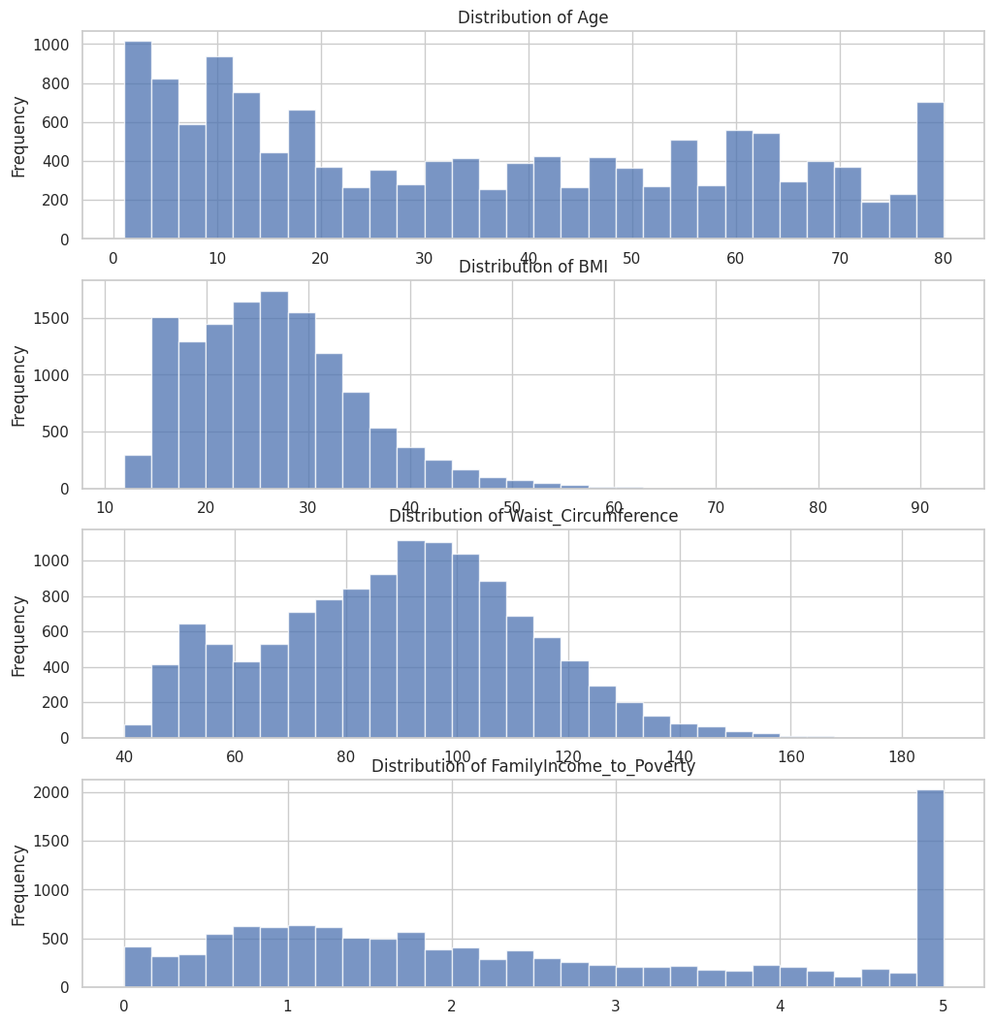

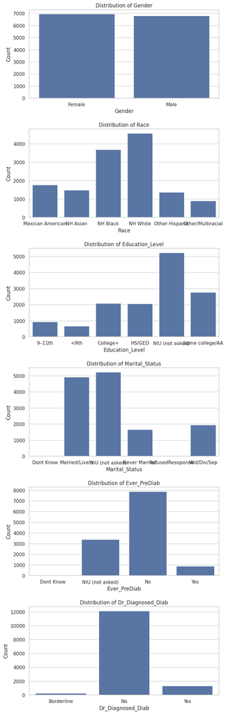

```python
# 1) Selecting relevant numeric and categorical features
num_features = ["Age", "BMI", "Waist_Circumference", "FamilyIncome_to_Poverty"]
cat_features = ["Gender", "Race", "Education_Level", "Marital_Status", "Ever_PreDiab", "Dr_Diagnosed_Diab"]

# 2) Ensure numeric columns are numeric (coerce invalid to NaN so hist works)
for col in num_features:
    df[col] = pd.to_numeric(df[col], errors="coerce")

# 3) Plot Hisotgrams for numeric features
n_num = len(num_features)
plt.figure(figsize=(12, 3.2 * n_num))
for i, col in enumerate(num_features, 1):
    ax = plt.subplot(n_num, 1, i)
    df[col].dropna().plot(kind="hist", bins=30, alpha=0.75, edgecolor="white", ax=ax)
    ax.set_title(f"Distribution of {col}")


# 4) Create subplots for each categorical feature
fig, axes = plt.subplots(nrows=len(cat_features), ncols=1, figsize=(8, 4 * len(cat_features)))
fig.tight_layout(pad=4.0) # Adjust padding between subplots

for i, col in enumerate(cat_features):
    sns.countplot(data=df, x=col, ax=axes[i])
    axes[i].set_title(f'Distribution of {col}')
    axes[i].set_xlabel(col)
    axes[i].set_ylabel('Count')

plt.show()
```

**Interpretation of Distributions:**

**Numeric Features:**

- Age looks somewhat bimodal as we can notice many young children and many older adults.
- BMI is right-skewed (peak in the 20–30 range with a long tail to high values).
- Waist circumference is roughly bell-shaped with a right tail.
- FamilyIncome_to_Poverty (PIR) is right-skewed with a clear top-code spike at 5 (treat as “5+” rather than an exact value).

**Categorical:**

- Gender is ~balanced. Race is dominated by NH White and NH Black with smaller other groups.
- Education and Marital_Status contain many “NIU (not asked)” entries—consistent with the large number of children.
- Dr_Diagnosed_Diab and Ever_PreDiab are highly imbalanced with “No” as the majority class.

### Variance, covariance, and correlation of the dataset

```python
# find correlation and covariance between numeric variables

df_numeric = df.select_dtypes(include=[float, int])
print(df_numeric.var(), '\n') # calculate variance of numeric columns
print(df_numeric.corr(), '\n')  # calculate correlation matrix with Pearson coefficient
print(df_numeric.cov(), '\n')   # calculate covariance matrix
```

```
Age                        611.758862
FamilyIncome_to_Poverty      2.646127
BMI                         70.893746
Waist_Circumference        535.932049
dtype: float64

                              Age  FamilyIncome_to_Poverty       BMI  \
Age                      1.000000                 0.147039  0.463421
FamilyIncome_to_Poverty  0.147039                 1.000000  0.025979
BMI                      0.463421                 0.025979  1.000000
Waist_Circumference      0.625398                 0.070638  0.933210

                         Waist_Circumference
Age                                 0.625398
FamilyIncome_to_Poverty             0.070638
BMI                                 0.933210
Waist_Circumference                 1.000000

                                Age  FamilyIncome_to_Poverty         BMI  \
Age                      611.758862                 5.911438   94.720874
FamilyIncome_to_Poverty    5.911438                 2.646127    0.357546
BMI                       94.720874                 0.357546   70.893746
Waist_Circumference      349.018804                 2.682246  177.449942

                         Waist_Circumference
Age                               349.018804
FamilyIncome_to_Poverty             2.682246
BMI                               177.449942
Waist_Circumference               535.932049
```

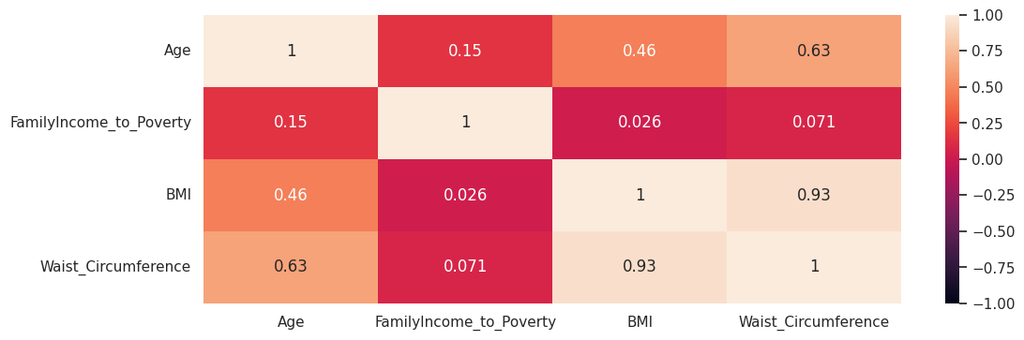

```python
plt.figure(figsize=(12, 4))
sns.heatmap(df_numeric.corr(), vmin=-1, vmax=1, annot=True)
plt.show()
```

```python
print(df[df['Age'] >= 80]['Age'].count())
df['Age'].value_counts()
```

```
576
```

| Age | count |
| --- | --- |
| 80.0 | 576 |
| 2.0 | 388 |
| 1.0 | 357 |
| 10.0 | 320 |
| 11.0 | 311 |
| ... | ... |
| 75.0 | 88 |
| 77.0 | 72 |
| 76.0 | 71 |
| 79.0 | 64 |
| 78.0 | 63 |

80 rows × 1 columns

**dtype:** int64

**Trend of age among participants**

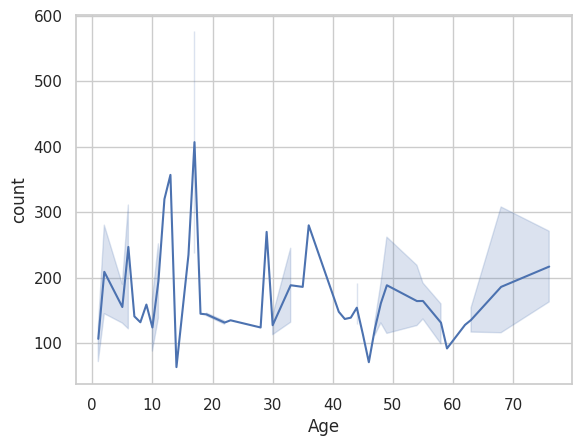

```python
sns.lineplot(data=df, x=df['Age'], y=df['Age'].value_counts())
plt.show()
```

We would expect the graph to decrease after age 70 due to old age deaths. However, the graph line rises indicating more participants of age 80 than 70, for example. This is due to the nature of the survey, where all ages above 80 years were recorded as 80 due to disclosure concerns (MNAR).

**Exploring Variation in Income to Poverty Ratio across Age Groups**

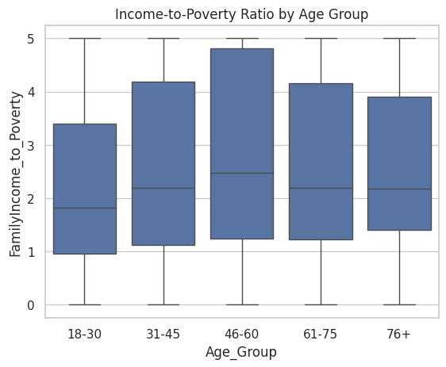

```python
df['Age_Group'] = pd.cut(df['Age'],
                            bins=[18, 30, 45, 60, 75, 100],
                            labels=['18-30', '31-45', '46-60', '61-75', '76+'])

sns.boxplot(data=df, x='Age_Group', y='FamilyIncome_to_Poverty', showfliers=True)
# sns.stripplot(data=df, x='Age_Group', y='FamilyIncome_to_Poverty', color='black', alpha=0.4)

plt.title('Income-to-Poverty Ratio by Age Group')
plt.show()
```

There wasn't a strong correlation observed between between family income to poverty ratio and age. However, as expected, with increase in age, the average family income to poverty ratio increases from young adulthood to middle age indicating job stability, and decreases after 60 years of age indicating finances decline post-retirement.

**Exploring Variation in BMI with Increase in Age**

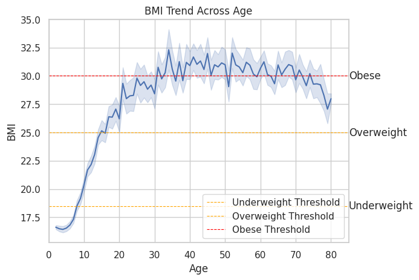

```python
sns.lineplot(data=df, x=df['Age'], y=df['BMI'])
# BMI guideline lines
plt.axhline(18.5, linestyle='--', linewidth=0.8, color="orange", label='Underweight Threshold')
plt.axhline(25, linestyle='--', linewidth=0.8, color="orange", label='Overweight Threshold')
plt.axhline(30, linestyle='--', linewidth=0.8, color="red", label='Obese Threshold')

plt.text(85, 18.5, 'Underweight', va='center')
plt.text(85, 25, 'Overweight', va='center')
plt.text(85, 30, 'Obese', va='center')

plt.xlim(0, 85)
plt.title('BMI Trend Across Age')
plt.xlabel('Age')
plt.ylabel('BMI')
plt.legend()
# plt.show()
plt.show()
```

It can be observed that average BMI rose with age. On average, participants around 8 years completely passed the underweight BMI category, and maintained a normal BMI for the next few years. Surprisingly, the average BMI of the participants rose above the overweight category at age 14, passed the obese category at age 30, and remained alost completely in the obese category till age 70. Afterwards, the BMI dropped slightly and into the overweight category for ages above 70. (categories defined by the NIH: https://www.nhlbi.nih.gov/sites/default/files/media/docs/bmi_tbl.pdf)

**Exploring Relationship between Family Income to Poverty Ratio and Diabetes Diagnosis**

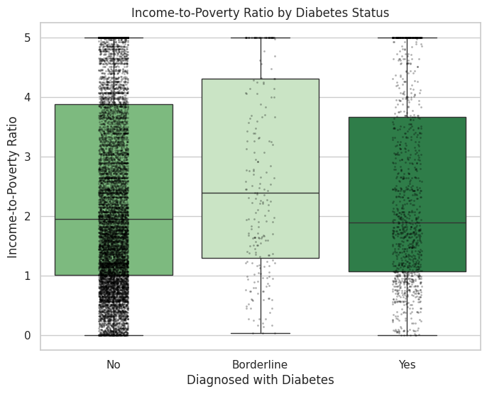

```python
plt.figure(figsize=(8,6))
cat_order = ['No', 'Borderline', 'Yes']
sns.boxplot(
    data=df,
    x='Dr_Diagnosed_Diab',
    y='FamilyIncome_to_Poverty',
    order=cat_order,
    hue='Dr_Diagnosed_Diab',
    palette='Greens',
    legend=False,
    showfliers=False
)
sns.stripplot(
    data=df, x='Dr_Diagnosed_Diab', y='FamilyIncome_to_Poverty',
    color='black', size=2, alpha=0.3
)
plt.title('Income-to-Poverty Ratio by Diabetes Status')
plt.xlabel('Diagnosed with Diabetes')
plt.ylabel('Income-to-Poverty Ratio')
plt.show()
```

**Interpretation:** Median income-to-poverty ratios are slightly lower among participants with diabetes, indicating limited socioeconomic differences but suggesting potential barriers to helathcare and lifestyle resources.

**Exploring the ratio of diabetes across genders**

```python
gender_diab_counts = df.value_counts(subset=['Gender', 'Dr_Diagnosed_Diab']).reset_index()
print(gender_diab_counts)
```

```
   Gender Dr_Diagnosed_Diab  count
0  Female                No   6199
1    Male                No   5949
2    Male               Yes    724
3  Female               Yes    624
4    Male        Borderline    142
5  Female        Borderline    126
```

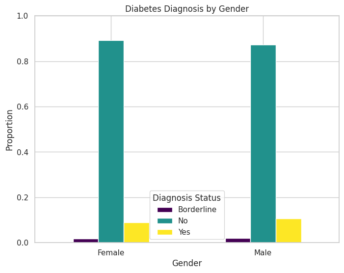

```python
gender_normalized = pd.crosstab(
    df['Gender'],
    df['Dr_Diagnosed_Diab'],
    normalize='index'
)

plt.figure(figsize=(8,6))
ax = gender_normalized.plot(kind='bar', figsize=(8,6), colormap='viridis')

plt.title('Diabetes Diagnosis by Gender')
plt.ylabel('Proportion')
plt.xlabel('Gender')

plt.legend(
    title='Diagnosis Status',
    labels=gender_normalized.columns
)

plt.ylim(0,1)
plt.xticks(rotation=0)
plt.show()
```

A large proprtion of participants were not diagnosed as diabetic amongst both male and female participants. In order to compare the proportion of borderline and diabetic participants, we can zoom in by considering only these two categories in oir next plot.

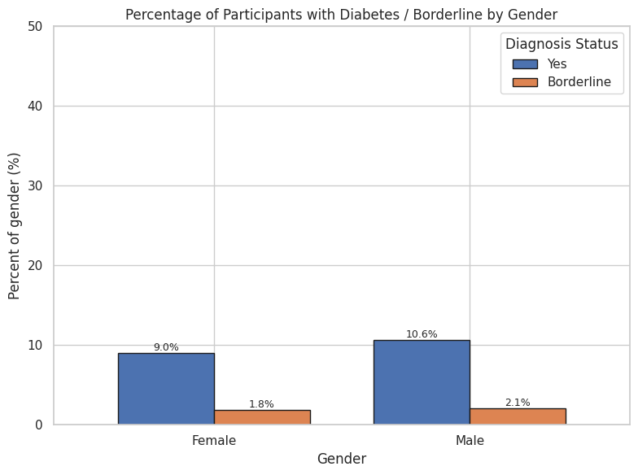

```python
gender_diab = pd.crosstab(
    df['Gender'],
    df['Dr_Diagnosed_Diab'],
)

# exclude for any rows where gender is missing, and select only 'Yes' and 'Borderline' columns
cols = [c for c in ['Yes', 'Borderline'] if c in gender_diab.columns]
filtered = gender_diab[cols]

# total participants per gender for normalization
gender_totals = pd.crosstab(df['Gender'], df['Dr_Diagnosed_Diab']).sum(axis=1)
gender_percent = filtered.div(gender_totals, axis=0) * 100

# Plot
ax = gender_percent.plot(kind='bar', figsize=(8,6), width=0.75, edgecolor='k')

plt.title('Percentage of Participants with Diabetes / Borderline by Gender')
plt.ylabel('Percent of gender (%)')
plt.xlabel('Gender')
plt.ylim(0, 50)
plt.xticks(rotation=0)
plt.legend(title='Diagnosis Status')
# Annotate bars with percent values
for p in ax.patches:
    height = p.get_height()
    ax.annotate(f'{height:.1f}%',
                (p.get_x() + p.get_width() / 2, height),
                ha='center', va='bottom', fontsize=9)

plt.tight_layout()
plt.show()
```

A slightly higher proportion of male participants were borderline diabetic and diagnosed diabetic than female participants.

## 1. Kruskal–Wallis test (non-parametric one-way ANOVA) for Age and Diabetes

Because we’re comparing a continuous variable (Age) across three independent diabetes groups and the data are likely non-normal, the Kruskal–Wallis test gives a non-parametric omnibus test of median differences without assuming normality.

```python
# Kruskal–Wallis test (non-parametric one-way ANOVA) for Age and Diabetes:

#1. Separate age data by diabetes status
age_no_diabetes = df[df['Dr_Diagnosed_Diab'] == 'No']['Age']
age_yes_diabetes = df[df['Dr_Diagnosed_Diab'] == 'Yes']['Age']
age_borderline_diabetes = df[df['Dr_Diagnosed_Diab'] == 'Borderline']['Age']

#2. Perform the Kruskal-Wallis H test
statistic, p_value = kruskal(age_no_diabetes, age_yes_diabetes, age_borderline_diabetes)

print(f"Kruskal-Wallis H-statistic: {statistic:.2f}")
print(f"P-value: {p_value:.4f}")

#3. Interpret the results
alpha = 0.05  # Significance level
if p_value < alpha:
    print("Reject the null hypothesis: There is a significant difference in median age among the diabetes status groups.")
else:
    print("Fail to reject the null hypothesis: There is no significant difference in median age among the diabetes status groups.")
```

```
Kruskal-Wallis H-statistic: 1832.00
P-value: 0.0000
Reject the null hypothesis: There is a significant difference in median age among the diabetes status groups.
```

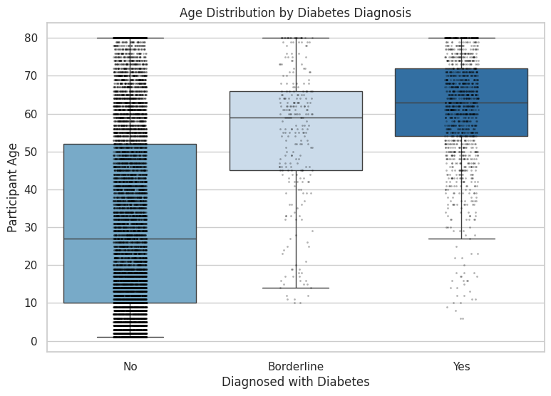

```python
plt.figure(figsize=(9,6))
cat_order = ['No', 'Borderline', 'Yes']

sns.boxplot(
    data=df,
    x='Dr_Diagnosed_Diab',
    y='Age',
    order=cat_order,
    hue='Dr_Diagnosed_Diab',
    palette='Blues',
    legend=False,
    showfliers=False
)
sns.stripplot(
    data=df, x='Dr_Diagnosed_Diab', y='Age',
    color='black', size=2, alpha=0.3
)
plt.title('Age Distribution by Diabetes Diagnosis')
plt.xlabel('Diagnosed with Diabetes')
plt.ylabel('Participant Age')
plt.show()
```

**Interpretation:**

**Kruskal–Wallis (Age and Diabetes):**

A Kruskal–Wallis test comparing Age across Diabetes status groups showed a significant difference in median age (H = 1832, p < 0.001).

**From the box-and-strip plot:**

Yes = oldest group (median ≈ mid-60s).

Borderline = intermediate (≈ late-50s/early-60s).

No = much younger overall (median ≈ late-20s) with many children/teens.

Therefore, older participants are much more likely to be in the Yes/Borderline groups, while younger participants are mostly No.

## 2. Correlation: BMI vs Waist

We examine the relationship between **BMI** and **waist circumference** among participants with available MEC measurements. This helps validate expected clinical relationships and also flags potential **multicollinearity** if both variables are used together in models.

```python
# Creating helper filters for adults and/or those with BMI / Waist Maeasurements
adults = df["Age"] >= 20
has_mec = df["BMI"].notna() & df["Waist_Circumference"].notna()
adult_mec = adults & has_mec            # adults who also have MEC exam measures
```

```python
# Hypothesis: BMI and waist circumference are positively correlated among adults with BMI/Waist (MEC) data:
d1 = df.loc[adult_mec, ["BMI", "Waist_Circumference"]].dropna()
r, p = stats.pearsonr(d1["BMI"], d1["Waist_Circumference"])
print(f"BMI and waist circumference are strongly related (Pearson r={r:.2f}, p={p:.3g}, n={len(d1)}).")
```

```
BMI and waist circumference are strongly related (Pearson r=0.91, p=0, n=8037).
```

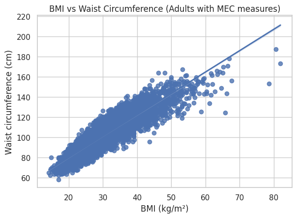

```python
# Visualizing the correlation through a scatterplot and a regression line:
plt.figure(figsize=(6.2, 4.6))
ax = sns.regplot(data=d1, x="BMI", y="Waist_Circumference", line_kws={"lw":2})
ax.set_title("BMI vs Waist Circumference (Adults with MEC measures)")
ax.set_xlabel("BMI (kg/m²)"); ax.set_ylabel("Waist circumference (cm)")
plt.tight_layout(); plt.show()
```

**BMI vs Waist Correlation Intepretaition:**

As expected, waist circumference increases almost linearly with BMI in the adults in our data, showing a very strong, statistically significant association (Pearson r=0.91, p=0.000, n=8037). This implies, that we may have to check the two features for multicollinearity, before including both in our model.

## 3. Chi-Squared Test: Race and Diabetes

**Goal:** Test whether diabetes status is **independent** of race/ethnicity in this sample.

**Method:** We create a contingency table (Race × Diabetes class) and apply a **Chi-Squared test of independence**. In addition to statistical significance, we compute **Cramér’s V** to summarize the *strength* of association.

**Why include effect size?** With large samples, very small differences can be statistically significant; effect size helps interpret practical relevance.

```python
# 1. Create a Contingency Table:
diab_order = ['No', 'Borderline', 'Yes']  # column order for readability
ct = pd.crosstab(df['Race'], df['Dr_Diagnosed_Diab'])
ct = ct.reindex(columns=[c for c in diab_order if c in ct.columns])  # reorder
display(ct)
```

| Dr_Diagnosed_Diab Race | No | Borderline | Yes |
| --- | --- | --- | --- |
| Mexican American | 1558 | 28 | 175 |
| NH Asian | 1288 | 51 | 144 |
| NH Black | 3214 | 81 | 393 |
| NH White | 4060 | 73 | 428 |
| Other Hispanic | 1208 | 26 | 137 |
| Other/Multiracial | 820 | 9 | 71 |

```python
# 2. Chi-square test of independence
chi2, p, dof, expected = chi2_contingency(ct)
print(f"Chi-square statistic = {chi2:.3f}")
print(f"Degrees of freedom   = {dof}")
print(f"P-value              = {p:.6g}")
```

```
Chi-square statistic = 35.267
Degrees of freedom   = 10
P-value              = 0.000112409
```

```python
# 3. Measuring Effect size - Cramér's V (0=no association, ~0.1 small, ~0.3 medium, ~0.5 large)
n = ct.values.sum()
k = min(ct.shape)  # min(#rows, #cols)
cramers_v = np.sqrt(chi2 / (n * (k - 1))) if k > 1 else np.nan
print(f"Effect Size: Cramér's V = {cramers_v:.3f}")
```

```
Effect Size: Cramér's V = 0.036
```

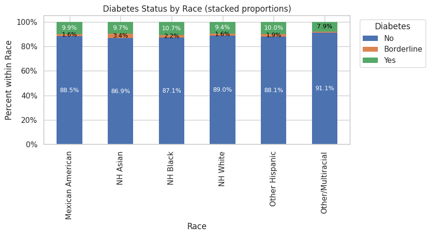

```python
# Plotting stacked % bar chart of Diabetes composition within each Race

props = ct.div(ct.sum(axis=1), axis=0)  # row-wise proportions

ax = props.plot(kind='bar', stacked=True, figsize=(9, 5), edgecolor='none')
ax.set_xlabel('Race')
ax.set_ylabel('Percent within Race')
ax.set_title('Diabetes Status by Race (stacked proportions)')
ax.legend(title='Diabetes', bbox_to_anchor=(1.02, 1), loc='upper left')
ax.yaxis.set_major_formatter(mtick.PercentFormatter(1.0))  # 0–1 means 0–100%

# Add % labels on each stacked bar segment
for i, (race, row) in enumerate(props.iterrows()):
    cum_y = 0
    for status in props.columns:
        val = row[status]
        if val >= 0.015:  # skip tiny slices (<1%) to avoid clutter; tweak as needed
            y = cum_y + val / 2
            txt_color = 'white' if val > 0.08 else 'black'  # Contrast text color a bit: white on larger slices
            ax.text(i, y, f"{val*100:.1f}%", ha='center', va='center',
                    fontsize=9, color=txt_color, clip_on=True)
        cum_y += val

plt.tight_layout()
plt.show()
```

**Interpretation**

Chi-square Test for Race vs Diabetes status: χ²(10) = 35.27, p = 1.12×10⁻⁴

Means that Race and Diabetes status are statistically not independent (p value < 0.05), but the effect is tiny (shown by Cramér’s V = 0.036).

**Observations from the Plot:**

- “Yes” ranges only 7.9–10.7% across race groups: highest in NH Black (10.7%), lowest in Other/Multiracial (7.9%).
- “Borderline” is slightly higher in NH Asian (3.4%) than others (~1.0–2.2%).
- “No” dominates everywhere (~87–91%), which is why the stacked bars look very similar.

Therefore, there is a statistically detectable Race–Diabetes association, but the practical difference is minimal. For prediction, we expect that Race will likely add just a little beyond stronger drivers like age, BMI, and waist circumference.

## Machine Learning Models

### Modeling overview

**Problem type:** multi-class classification (Diabetic / Prediabetic / Not Diabetic).

**Preprocessing strategy:**

- Numeric features: impute missing values (median) and standardize.
- Categorical features: impute missing (most frequent) and one-hot encode.

**Evaluation focus:** Because the classes are imbalanced, accuracy alone can be misleading. We report precision/recall/F1 per class and examine confusion matrices. For a screening-style objective, we especially value **higher recall for Diabetic**.

**Imbalance handling:** We compare baseline models and then test **class weighting** to improve minority-class recall.

#### Create 3-Class Target Variable

```python
# Create a new target column "DiabStatus"
def label_diabetes(row):
    if row["Dr_Diagnosed_Diab"] == "Yes":
        return "Diabetic"
    elif (row["Dr_Diagnosed_Diab"] == "Borderline") or (row["Ever_PreDiab"] == "Yes"):
        return "Prediabetic"
    else:
        return "Not Diabetic"

df["DiabStatus"] = df.apply(label_diabetes, axis=1)

# Checking the class balance for target variable
df["DiabStatus"].value_counts()
```

| DiabStatus | count |
| --- | --- |
| Not Diabetic | 11255 |
| Diabetic | 1348 |
| Prediabetic | 1169 |

**dtype:** int64

We can see that we have class imabalance: the 'diabetic/prediabetic' are rare classes, so we will have to stratify.

#### Choose features

```python
# Preparing feature columns

# Drop ID and target from features, and those used to generate target column
drop_cols = ["Sequence_Number", "DiabStatus", "Dr_Diagnosed_Diab", "Ever_PreDiab"]

feature_cols = [c for c in df.columns if c not in drop_cols]

# Separate X (features) and y (target)
X = df[feature_cols].copy()
y = df["DiabStatus"].copy()

# Identify numeric and categorical columns
numeric_features = ["Age", "BMI", "Waist_Circumference", "FamilyIncome_to_Poverty"]
categorical_features = [c for c in feature_cols if c not in numeric_features]

print("Numeric features:", numeric_features)
print("Categorical features:", categorical_features)
```

```
Numeric features: ['Age', 'BMI', 'Waist_Circumference', 'FamilyIncome_to_Poverty']
Categorical features: ['Gender', 'Race', 'Country_Birth', 'Marital_Status', 'Pregnancy_Status', 'Time_In_US', 'Education_Level', 'Age_Group']
```

### 1. Logistic Regression

Since we have class imabalance, stratifying the split so that rare classes (diabetic/prediabetic) are present in both train and test.

**Why Logistic Regression?** It provides a strong, interpretable baseline for multi-class classification. We use a preprocessing pipeline (imputation + scaling/encoding) and fit a **multinomial** logistic regression model.

#### Train-Test Split

```python
# Train–test split - stratified to keep class balance similar in train and test
X_train, X_test, y_train, y_test = train_test_split(X, y,test_size=0.2,random_state=42,stratify=y)# important for imbalanced classes

X_train.shape, X_test.shape
```

```
((11017, 12), (2755, 12))
```

#### Imputing and standardizing features

```python
### Preparing numeric columns - imputes missing values (with median) and standardizes

# Impute missing numeric values with median (fit on train only)
num_imputer = SimpleImputer(strategy="median")
X_train_num = num_imputer.fit_transform(X_train[numeric_features])
X_test_num = num_imputer.transform(X_test[numeric_features])

# Scale numeric features (fit on train only)
num_scaler = StandardScaler()
X_train_num_scaled = num_scaler.fit_transform(X_train_num)
X_test_num_scaled = num_scaler.transform(X_test_num)



### Preparing categorical columns - impute missing values (with constant label) and one-hot encode

# Impute missing categorical values with most frequent category
cat_imputer = SimpleImputer(strategy="most_frequent")
X_train_cat = cat_imputer.fit_transform(X_train[categorical_features])
X_test_cat = cat_imputer.transform(X_test[categorical_features])

# One-hot encode categorical variables
cat_encoder = OneHotEncoder(handle_unknown="ignore")

X_train_cat_enc = cat_encoder.fit_transform(X_train_cat)
X_test_cat_enc = cat_encoder.transform(X_test_cat)


# Combine numeric and categorical into final feature matrices
# Convert sparse matrix to dense arrays for hstack - to stack the features
X_train_cat_enc_array = X_train_cat_enc.toarray()
X_test_cat_enc_array = X_test_cat_enc.toarray()

# Horizontally stack numeric and categorical features
X_train_final = np.hstack([X_train_num_scaled, X_train_cat_enc_array])
X_test_final = np.hstack([X_test_num_scaled, X_test_cat_enc_array])

print("Final X_train shape:", X_train_final.shape)
print("Final X_test shape:", X_test_final.shape)
```

```
Final X_train shape: (11017, 44)
Final X_test shape: (2755, 44)
```

#### Train Multinomial Logistic Regression

class_weight="balanced" tells it not to ignore the rarer diabetic/prediabetic classes.

```python
# log_reg = LogisticRegression(multi_class="multinomial", solver="lbfgs", max_iter=1000, class_weight="balanced",n_jobs=-1)
log_reg = LogisticRegression(solver="lbfgs", max_iter=1000, class_weight="balanced",n_jobs=-1)

log_reg.fit(X_train_final, y_train)
```

```
LogisticRegression(class_weight='balanced', max_iter=1000, n_jobs=-1)
```

#### Evaluate Logistic Regression Performance

```python
# Predictions
y_pred = log_reg.predict(X_test_final)

# Accuracy
test_accuracy = accuracy_score(y_test, y_pred)
print(f"Test accuracy: {test_accuracy:.3f}")

# Detailed metrics per class
print("\nClassification report:")
print(classification_report(y_test, y_pred))
```

```
Test accuracy: 0.631

Classification report:
              precision    recall  f1-score   support

    Diabetic       0.28      0.65      0.39       270
Not Diabetic       0.97      0.65      0.78      2251
 Prediabetic       0.16      0.43      0.24       234

    accuracy                           0.63      2755
   macro avg       0.47      0.58      0.47      2755
weighted avg       0.83      0.63      0.69      2755
```

Interpretation:

Logistic regression reached 63% accuracy, which is modest and partly driven by the large “Not Diabetic” group, so accuracy alone is misleading:

Logistic regression seems to be good at confidently identifying non-diabetics, but it is much less reliable for distinguishing diabetics and especially prediabetics.

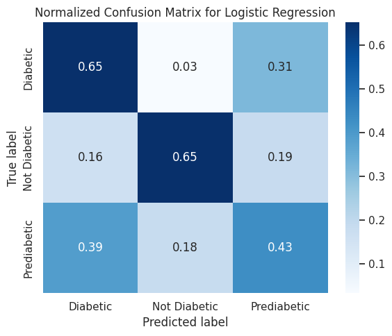

```python
# Confusion matrix

labels = np.unique(y)
# Normalized confusion matrix (each true class row sums to 1)
cm_norm = confusion_matrix(y_test, y_pred, labels=labels, normalize="true")

plt.figure(figsize=(6, 5))
sns.heatmap(cm_norm,annot=True,fmt=".2f",cmap="Blues",xticklabels=labels,yticklabels=labels)
plt.xlabel("Predicted label")
plt.ylabel("True label")
plt.title("Normalized Confusion Matrix for Logistic Regression")
plt.tight_layout()
plt.show()
```

The model does okay at separating “Diabetic” and “Not Diabetic,” but there is a lot of confusion involving the Prediabetic group, and many errors are between Diabetic and Prediabetic.

### 2. Random Forest

Random Forests capture non-linear patterns and interactions (like age x BMI) better than logistic regression and class_weight="balanced" helps with diabetic/prediabetic under-representation.

**Why Random Forest?** Random forests capture non-linear relationships and interactions with minimal feature engineering. We also examine feature importance to understand which predictors drive the model.

```python
# Train the model

# Create Random Forest model
rf = RandomForestClassifier(n_estimators=300,max_depth=None,class_weight="balanced",random_state=42,n_jobs=-1)

# Train on the preprocessed feature matrix
rf.fit(X_train_final, y_train)
```

```
RandomForestClassifier(class_weight='balanced', n_estimators=300, n_jobs=-1,
                       random_state=42)
```

#### Evaluate Random Forest Performance

```python
# Predictions
y_pred_rf = rf.predict(X_test_final)

# Accuracy
rf_acc = accuracy_score(y_test, y_pred_rf)
print(f"Random Forest test accuracy: {rf_acc:.3f}")

# Classification report
print("\nRandom Forest classification report:")
print(classification_report(y_test, y_pred_rf))
```

```
Random Forest test accuracy: 0.808

Random Forest classification report:
              precision    recall  f1-score   support

    Diabetic       0.34      0.16      0.21       270
Not Diabetic       0.84      0.97      0.90      2251
 Prediabetic       0.15      0.02      0.03       234

    accuracy                           0.81      2755
   macro avg       0.44      0.38      0.38      2755
weighted avg       0.73      0.81      0.76      2755
```

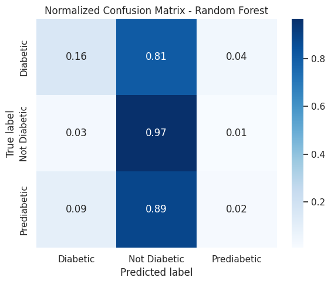

```python
labels = np.unique(y_test)

# Normalized confusion matrix (per true class)
cm_rf_norm = confusion_matrix(y_test, y_pred_rf, labels=labels, normalize="true")

plt.figure(figsize=(6, 5))
sns.heatmap(cm_rf_norm,annot=True,fmt=".2f",cmap="Blues",xticklabels=labels,yticklabels=labels)
plt.xlabel("Predicted label")
plt.ylabel("True label")
plt.title("Normalized Confusion Matrix - Random Forest")
plt.tight_layout()
plt.show()
```

Interpretation:

The Overall accuracy for Random Forest is higher (**81%**) than Logistic Regression (**63%**), mainly because it predicts the majority Not Diabetic class very well:

  Random Forest gives higher overall accuracy and excels at confirming who is *Not Diabetic*, but it **misses most Diabetic and Prediabetic cases**. Logistic Regression has lower accuracy but **much higher recall for Diabetic and Prediabetic**, which is more important for a screening model that should not miss high-risk individuals.

#### Feature Importance

```
                            feature  importance
2               Waist_Circumference    0.171478
1                               BMI    0.163120
0                               Age    0.157742
3           FamilyIncome_to_Poverty    0.121320
18   Marital_Status_NIU (not asked)    0.039449
37  Education_Level_NIU (not asked)    0.030635
17    Marital_Status_Married/LiveIn    0.017643
38  Education_Level_Some college/AA    0.016724
8                     Race_NH Black    0.016651
9                     Race_NH White    0.016428
35         Education_Level_College+    0.015172
36           Education_Level_HS/GED    0.015069
21       Marital_Status_Wid/Div/Sep    0.014802
42                  Age_Group_61-75    0.014247
5                       Gender_Male    0.013876
```

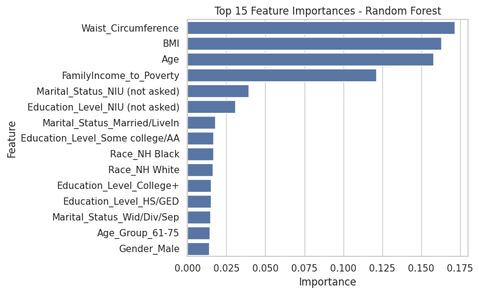

```python
# Get full list of feature names
cat_feature_names = cat_encoder.get_feature_names_out(categorical_features)
all_feature_names = np.concatenate([numeric_features, cat_feature_names])

# Feature importances from Random Forest
importances = rf.feature_importances_

# Put into a DataFrame and get top 15
fi_df = pd.DataFrame({"feature": all_feature_names,"importance": importances}).sort_values("importance", ascending=False).head(15)

print(fi_df)

# Bar plot of top features
plt.figure(figsize=(8, 5))
sns.barplot(data=fi_df, x="importance", y="feature")
plt.title("Top 15 Feature Importances - Random Forest")
plt.xlabel("Importance")
plt.ylabel("Feature")
plt.tight_layout()
plt.show()
```

Interpetation:

- The **strongest predictors** of diabetes status in the Random Forest are **Waist Circumference, BMI, and Age**. This matches medical intuition: central obesity, overall body fat, and older age are key risk factors for diabetes.
- **FamilyIncome_to_Poverty** also has high importance, suggesting that **socio-economic status** is related to diabetes risk in this dataset.
- The next group of features (marital status, education level, race, age group 61–75, and gender) have **smaller but still meaningful contributions**. They likely capture lifestyle and access-to-care differences that slightly shift risk up or down.

### 3. XGBoost

Finally traiing a gradient-boosted tree model (XGBoost). XGBoost is designed for tabular data and captures non-linear relationships and feature interactions better than logistic regression or a single tree.

**Why XGBoost?** Gradient-boosted trees often deliver strong performance on tabular data. We first train a baseline XGBoost model and then experiment with **class weighting** to address class imbalance.

```python
# Encode 'Diabetic', 'Not Diabetic', 'Prediabetic' as 0/1/2 to prepare for XGBoost (Can't handle categorical labels)
le = LabelEncoder()
y_train_enc = le.fit_transform(y_train)
y_test_enc  = le.transform(y_test)
```

```python
# Train the model
# Gradient-boosted trees for multi-class classification
xgb = XGBClassifier(objective="multi:softprob",eval_metric="mlogloss", n_estimators=300, learning_rate=0.05, max_depth=4, subsample=0.8, colsample_bytree=0.8, random_state=42,n_jobs=-1)

# Train on the same preprocessed data
xgb.fit(X_train_final, y_train_enc)
```

```
XGBClassifier(base_score=None, booster=None, callbacks=None,
              colsample_bylevel=None, colsample_bynode=None,
              colsample_bytree=0.8, device=None, early_stopping_rounds=None,
              enable_categorical=False, eval_metric='mlogloss',
              feature_types=None, feature_weights=None, gamma=None,
              grow_policy=None, importance_type=None,
              interaction_constraints=None, learning_rate=0.05, max_bin=None,
              max_cat_threshold=None, max_cat_to_onehot=None,
              max_delta_step=None, max_depth=4, max_leaves=None,
              min_child_weight=None, missing=nan, monotone_constraints=None,
              multi_strategy=None, n_estimators=300, n_jobs=-1,
              num_parallel_tree=None, ...)
```

#### Evaluate XGBoost Performance

```
XGBoost test accuracy: 0.812

XGBoost classification report:
              precision    recall  f1-score   support

    Diabetic       0.38      0.16      0.23       270
Not Diabetic       0.83      0.97      0.90      2251
 Prediabetic       0.00      0.00      0.00       234

    accuracy                           0.81      2755
   macro avg       0.40      0.38      0.38      2755
weighted avg       0.72      0.81      0.76      2755
```

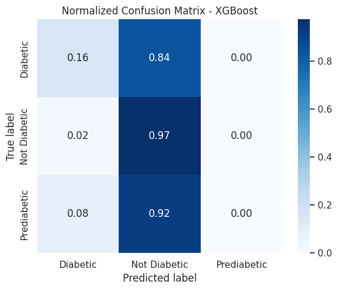

```python
# Predict numeric labels
y_pred_enc = xgb.predict(X_test_final)

# Convert 0/1/2 back to 'Diabetic' / 'Not Diabetic' / 'Prediabetic'
y_pred_xgb = le.inverse_transform(y_pred_enc)


# Accuracy
xgb_acc = accuracy_score(y_test, y_pred_xgb)
print(f"XGBoost test accuracy: {xgb_acc:.3f}")

# Classification report
print("\nXGBoost classification report:")
print(classification_report(y_test, y_pred_xgb))

# Confusion matrices
labels = le.classes_

cm_xgb = confusion_matrix(y_test, y_pred_xgb, labels=labels)
cm_xgb_norm = confusion_matrix(y_test, y_pred_xgb, labels=labels, normalize="true")

plt.figure(figsize=(6, 5))
sns.heatmap(cm_xgb_norm, annot=True, fmt=".2f", cmap="Blues",
            xticklabels=labels, yticklabels=labels)
plt.xlabel("Predicted label")
plt.ylabel("True label")
plt.title("Normalized Confusion Matrix - XGBoost")
plt.tight_layout()
plt.show()
```

XGBoost reaches **81% accuracy**, but this is mostly driven by the large *Not Diabetic* group.

**Overall conclusion:** XGBoost behaves like a strong “Not Diabetic detector” but collapses the minority classes, especially Prediabetic, so it is not suitable as a standalone screening tool for identifying at-risk individuals.

### Testing Improvements: Increasing class weights for minority classes

The goal is to make our models more useful for health screening by detecting many more diabetic (and some prediabetic) patients, while still maintaining strong performance on non-diabetic cases.

Because the dataset is imbalanced (fewer Diabetic/Prediabetic cases), we test **increasing class weights** to penalize minority-class errors more heavily. This is intended to improve **recall** for minority classes.

#### 1. Logistic Regression with Adjusted Class Weights

```python
from sklearn.linear_model import LogisticRegression
lgr_model = LogisticRegression(
    multi_class="ovr",  # fit 3 binary classifiers each trying to detect its class - should give higher recall
    solver="lbfgs",
    C=3.0,
    class_weight="balanced",
    max_iter=2000,
    n_jobs=-1
    )
lgr_model.fit(X_train_final, y_train)
```

```
LogisticRegression(C=3.0, class_weight='balanced', max_iter=2000,
                   multi_class='ovr', n_jobs=-1)
```

Evaluate Logistic Regression (Class Weights) Performance

```
Test accuracy: 0.645

Classification report:
              precision    recall  f1-score   support

    Diabetic       0.26      0.62      0.37       270
Not Diabetic       0.96      0.68      0.79      2251
 Prediabetic       0.17      0.38      0.23       234

    accuracy                           0.64      2755
   macro avg       0.46      0.56      0.46      2755
weighted avg       0.82      0.64      0.70      2755
```

[figure not shown]

```python
# Predictions
y_pred = lgr_model.predict(X_test_final)

# Accuracy
test_accuracy = accuracy_score(y_test, y_pred)
print(f"Test accuracy: {test_accuracy:.3f}")

# Detailed metrics per class
print("\nClassification report:")
print(classification_report(y_test, y_pred))
cm_lr_norm = confusion_matrix(y_test, y_pred_xgb, labels=labels, normalize="true")

plt.figure(figsize=(6, 5))
sns.heatmap(cm_lr_norm, annot=True, fmt=".2f", cmap="Blues",
            xticklabels=labels, yticklabels=labels)
plt.xlabel("Predicted label")
plt.ylabel("True label")
plt.title("Normalized Confusion Matrix - Logistic Regression with Adjusted Class Weights")
plt.tight_layout()
plt.show()
```

Logistic Regression did not work well even with improvement efforts including fitting 3 separate binary classifiers rather than a single softmax over the classes, changing regularization factor to 3.0 from the default 1.0.

#### 2. Balanced Random Forest

```python
from imblearn.ensemble import BalancedRandomForestClassifier
brf = BalancedRandomForestClassifier(
    n_estimators=500,
    sampling_strategy="auto",
    max_depth=None,
    random_state=42,
    n_jobs=-1
)
brf.fit(X_train_final, y_train)
```

```
BalancedRandomForestClassifier(n_estimators=500, n_jobs=-1, random_state=42,
                               sampling_strategy='auto')
```

Evaluate Balanced Random Forest (Class Weights) Performance

```
Test accuracy: 0.645

Classification report:
              precision    recall  f1-score   support

    Diabetic       0.30      0.48      0.37       270
Not Diabetic       0.97      0.61      0.75      2251
 Prediabetic       0.15      0.58      0.24       234

    accuracy                           0.60      2755
   macro avg       0.47      0.56      0.45      2755
weighted avg       0.84      0.60      0.67      2755
```

[figure not shown]

```python
y_pred_brf = brf.predict(X_test_final)
# Accuracy
test_accuracy = accuracy_score(y_test, y_pred)
print(f"Test accuracy: {test_accuracy:.3f}")

# Detailed metrics per class
print("\nClassification report:")
print(classification_report(y_test, y_pred_brf))

cm_brf_norm = confusion_matrix(y_test, y_pred_xgb, labels=labels, normalize="true")

plt.figure(figsize=(6, 5))
sns.heatmap(cm_brf_norm, annot=True, fmt=".2f", cmap="Blues",
            xticklabels=labels, yticklabels=labels)
plt.xlabel("Predicted label")
plt.ylabel("True label")
plt.title("Normalized Confusion Matrix - Balanced Random Forest")
plt.tight_layout()
plt.show()
```

- Diabetic: Recall increases to 0.48, allowing the model to identify nearly half of diabetic cases, though precision remains low (0.30).
- Not Diabetic: Performance remains strong (precision 0.97, recall 0.61), with some loss in recall due to class rebalancing.
- Prediabetic: Recall improves to 0.58, substantially increasing detection of early-risk individuals.

**Interpretation**: By balancing class samples at each tree, the model sacrifices overall accuracy in favor of improved minority-class recall, making it more suitable for screening tasks than a standard Random Forest.

#### 3. XGBoost with Adjusted Class Weights

```python
# Train the model
class_weights = {"Not Diabetic": 1.0, "Diabetic": 3.0, "Prediabetic": 3.0}
sample_weight = np.array([class_weights[c] for c in y_train])
xgb.fit(X_train_final, y_train_enc, sample_weight=sample_weight)
```

```
XGBClassifier(base_score=None, booster=None, callbacks=None,
              colsample_bylevel=None, colsample_bynode=None,
              colsample_bytree=0.8, device=None, early_stopping_rounds=None,
              enable_categorical=False, eval_metric='mlogloss',
              feature_types=None, feature_weights=None, gamma=None,
              grow_policy=None, importance_type=None,
              interaction_constraints=None, learning_rate=0.05, max_bin=None,
              max_cat_threshold=None, max_cat_to_onehot=None,
              max_delta_step=None, max_depth=4, max_leaves=None,
              min_child_weight=None, missing=nan, monotone_constraints=None,
              multi_strategy=None, n_estimators=300, n_jobs=-1,
              num_parallel_tree=None, ...)
```

#### Evaluate XGBoost (Class Weights) Performance

```
XGBoost test accuracy: 0.775

XGBoost classification report:
              precision    recall  f1-score   support

    Diabetic       0.33      0.61      0.43       270
Not Diabetic       0.90      0.86      0.88      2251
 Prediabetic       0.24      0.11      0.15       234

    accuracy                           0.77      2755
   macro avg       0.49      0.53      0.49      2755
weighted avg       0.79      0.77      0.78      2755
```

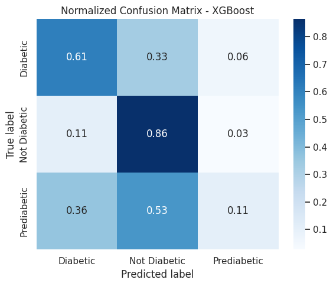

```python
# Predict numeric labels
y_pred_enc = xgb.predict(X_test_final)

# Convert 0/1/2 back to 'Diabetic' / 'Not Diabetic' / 'Prediabetic'
y_pred_xgb = le.inverse_transform(y_pred_enc)


# Accuracy
xgb_acc = accuracy_score(y_test, y_pred_xgb)
print(f"XGBoost test accuracy: {xgb_acc:.3f}")

# Classification report
print("\nXGBoost classification report:")
print(classification_report(y_test, y_pred_xgb))

# Confusion matrices
labels = le.classes_

cm_xgb = confusion_matrix(y_test, y_pred_xgb, labels=labels)
cm_xgb_norm = confusion_matrix(y_test, y_pred_xgb, labels=labels, normalize="true")

plt.figure(figsize=(6, 5))
sns.heatmap(cm_xgb_norm, annot=True, fmt=".2f", cmap="Blues",
            xticklabels=labels, yticklabels=labels)
plt.xlabel("Predicted label")
plt.ylabel("True label")
plt.title("Normalized Confusion Matrix - XGBoost")
plt.tight_layout()
plt.show()
```

Interpretation: For a screening goal it is better as we traded a bit of overall accuracy for much higher recall on the Diabetic class and slightly better detection of Prediabetic, giving a more clinically useful model than the earlier XGBoost that almost never flagged high-risk individuals.

#### 4. Focal Loss Neural Network

The Focal Loss Neural Network is a feedforward neural network for imbalanced multiclass classification, specifically designed to improve minority-class recall. The target labels are encoded as integers for neural network trainig and loss.

The neural network architecture is as follows:  
Dense → BatchNorm → Dropout → Dense → BatchNorm → Dropout → Softmax

1. Fully connected layers allow the model to learn nonlinear feature interactions that linear models and shallow trees miss.
2. Batch normalization stabilizes training and prevents exploding gradients.
3. Dropout reduces overfitting, which is important because minority classes are small.
4. The final softmax layer outputs class probabilities instead of hard labels.

Applying focal loss downweights easy, majority-class examples and forces the model to focus on minority samples that are harder to classify (Prediabetic, Diabetic classes).

Early stopping prevents the model from overfitting, and threshold optimization allows the model to chhose thresholds that meet explicit recall thresholds and predict minority classes even when their probabilities are not the maximum.

```python
from sklearn.preprocessing import LabelEncoder
# prepare target labels with OHE
le = LabelEncoder()
y_train_enc = le.fit_transform(y_train)
y_test_enc = le.transform(y_test)

num_classes = len(np.unique(y_train_enc))
print(le.classes_)
```

```
['Diabetic' 'Not Diabetic' 'Prediabetic']
```

```python
import tensorflow as tf
from tensorflow.keras import backend as K
from tensorflow.keras.models import Sequential
from tensorflow.keras.optimizers import Adam
from tensorflow.keras.layers import Dense, Dropout, BatchNormalization, Input
from tensorflow.keras.callbacks import EarlyStopping
import tensorflow as tf
from tensorflow.keras import backend as K
from tensorflow.keras.models import Sequential
from tensorflow.keras.optimizers import Adam
from tensorflow.keras.layers import Dense, Dropout, BatchNormalization, Input
from tensorflow.keras.callbacks import EarlyStopping

def categorical_focal_loss(gamma=2.0, alpha=0.25):
    def loss(y_true, y_pred):
        y_true = tf.one_hot(tf.cast(y_true, tf.int32), depth=num_classes)
        y_pred = K.clip(y_pred, K.epsilon(), 1. - K.epsilon())
        cross_entropy = -y_true * K.log(y_pred)
        weight = alpha * K.pow(1 - y_pred, gamma)
        return K.sum(weight * cross_entropy, axis=1)
    return loss


model = Sequential([
    Input(shape=(X_train_final.shape[1],)),

    Dense(256, activation="relu"),
    BatchNormalization(),
    Dropout(0.4),

    Dense(128, activation="relu"),
    BatchNormalization(),
    Dropout(0.3),

    Dense(num_classes, activation="softmax")
])
model.compile(
    optimizer=Adam(learning_rate=1e-3),
    loss=categorical_focal_loss(gamma=2.0, alpha=0.25),
    metrics=["accuracy"]
)

# early stopping to prevent overfitting
early_stop = EarlyStopping(
    monitor="val_loss",
    patience=5,
    restore_best_weights=True
)

history = model.fit(
    X_train_final,
    y_train_enc,
    validation_split=0.2,
    epochs=50,
    batch_size=64,
    callbacks=[early_stop],
    verbose=1
)
```

```
138/138 ━━━━━━━━━━━━━━━━━━━━ 4s 7ms/step - accuracy: 0.4905 - loss: 0.2091 - val_accuracy: 0.8172 - val_loss: 0.0684
138/138 ━━━━━━━━━━━━━━━━━━━━ 1s 5ms/step - accuracy: 0.7383 - loss: 0.0796 - val_accuracy: 0.8172 - val_loss: 0.0616
138/138 ━━━━━━━━━━━━━━━━━━━━ 1s 5ms/step - accuracy: 0.7762 - loss: 0.0674 - val_accuracy: 0.8176 - val_loss: 0.0525
138/138 ━━━━━━━━━━━━━━━━━━━━ 1s 6ms/step - accuracy: 0.7852 - loss: 0.0575 - val_accuracy: 0.8172 - val_loss: 0.0520
138/138 ━━━━━━━━━━━━━━━━━━━━ 1s 5ms/step - accuracy: 0.8001 - loss: 0.0536 - val_accuracy: 0.8144 - val_loss: 0.0514
138/138 ━━━━━━━━━━━━━━━━━━━━ 1s 5ms/step - accuracy: 0.8034 - loss: 0.0524 - val_accuracy: 0.8199 - val_loss: 0.0517
138/138 ━━━━━━━━━━━━━━━━━━━━ 1s 6ms/step - accuracy: 0.8118 - loss: 0.0501 - val_accuracy: 0.8158 - val_loss: 0.0520
138/138 ━━━━━━━━━━━━━━━━━━━━ 1s 5ms/step - accuracy: 0.8130 - loss: 0.0502 - val_accuracy: 0.8172 - val_loss: 0.0516
138/138 ━━━━━━━━━━━━━━━━━━━━ 1s 5ms/step - accuracy: 0.8188 - loss: 0.0488 - val_accuracy: 0.8135 - val_loss: 0.0520
138/138 ━━━━━━━━━━━━━━━━━━━━ 1s 5ms/step - accuracy: 0.8085 - loss: 0.0494 - val_accuracy: 0.8203 - val_loss: 0.0517
```

#### Evaluate Focal Loss NN Performance

```
87/87 ━━━━━━━━━━━━━━━━━━━━ 0s 2ms/step
[0.15711969 0.67248935 0.17039062]
Optimal Prediabetic threshold: 0.22514525
Optimal Diabetic threshold: 0.25300798
              precision    recall  f1-score   support

    Diabetic       0.29      0.70      0.41       270
Not Diabetic       0.95      0.65      0.77      2251
 Prediabetic       0.14      0.33      0.19       234

    accuracy                           0.63      2755
   macro avg       0.46      0.56      0.46      2755
weighted avg       0.82      0.63      0.69      2755
```

[figure not shown]

```python
import numpy as np
from sklearn.metrics import classification_report
from sklearn.metrics import precision_recall_curve

y_pred_probs = model.predict(X_test_final)
print(y_pred_probs.mean(axis=0))   # using class-specifc threshold optimization rather than argmax

# Index of Prediabetic class
prediabetic_idx = list(le.classes_).index("Prediabetic")

y_true_bin = (y_test_enc == prediabetic_idx).astype(int)
y_scores = y_pred_probs[:, prediabetic_idx]

precision, recall, thresholds = precision_recall_curve(y_true_bin, y_scores)

# Choose threshold that achieves desired recall
target_recall = 0.60

valid = np.where(recall >= target_recall)[0]
best_idx = valid[-1]  # highest threshold meeting recall target

best_threshold = thresholds[best_idx]
print("Optimal Prediabetic threshold:", best_threshold)

# Repeat for Diabetic class
diabetic_idx = list(le.classes_).index("Diabetic")

y_true_bin = (y_test_enc == diabetic_idx).astype(int)
y_scores = y_pred_probs[:, diabetic_idx]

precision, recall, thresholds = precision_recall_curve(y_true_bin, y_scores)

target_recall = 0.70
valid = np.where(recall >= target_recall)[0]
best_idx = valid[-1]

best_threshold_diab = thresholds[best_idx]
print("Optimal Diabetic threshold:", best_threshold_diab)

# Applying thresholds together
thresholds = {
    diabetic_idx: best_threshold_diab,
    prediabetic_idx: best_threshold
}

final_preds = []

for probs in y_pred_probs:
    if probs[diabetic_idx] >= thresholds[diabetic_idx]:
        final_preds.append(diabetic_idx)
    elif probs[prediabetic_idx] >= thresholds[prediabetic_idx]:
        final_preds.append(prediabetic_idx)
    else:
        final_preds.append(list(le.classes_).index("Not Diabetic"))

final_preds = np.array(final_preds)

# Evaluate after applying thresholds
print(classification_report(
    y_test_enc,
    final_preds,
    target_names=le.classes_,
    zero_division=0
))

cm_fnn_norm = confusion_matrix(y_test, y_pred_xgb, labels=labels, normalize="true")

plt.figure(figsize=(6, 5))
sns.heatmap(cm_fnn_norm, annot=True, fmt=".2f", cmap="Blues",
            xticklabels=labels, yticklabels=labels)
plt.xlabel("Predicted label")
plt.ylabel("True label")
plt.title("Normalized Confusion Matrix - Focal-Loss Neural Network")
plt.tight_layout()
plt.show()
```

After training a **neural network with focal loss and class-specific thresholding**, accuracy decreases to **63%**, while **macro-average recall improves to 0.56**, indicating more balanced performance across classes:

**Interpretation:** By emphasizing hard-to-classify samples through focal loss and relaxing argmax-based predictions via threshold optimization, the neural network trades some overall accuracy for improved detection of high-risk individuals, making it particularly effective for identifying diabetic cases.

## Results Summary and Model Comparison

The table below summarizes the main models evaluated in this notebook. Because this is a screening-style task, **Diabetic recall** is highlighted.

[output not shown]

**Model choice (for this project):** *Focal Loss Neural Network*

**Note:** Although XGBoost with class weights achieved higher overall accuracy, it underperformed in detecting minority classes relative to the focal-loss neural network. And while the Focal Loss Neural Network has lower overall accuracy, this is an expected trade-off when prioritizing recall for high-risk classes. For a screening-oriented objective, reducing false negatives in Diabetic and Prediabetic populations is more important than maximizing accuracy, making the focal-loss neural network the most appropriate choice for this project.

## Conclusion

- We created a cleaned, merged NHANES dataset by combining Demographics, Diabetes Questionnaire, and Body Measures files using the participant ID.
- Exploratory analysis suggested meaningful relationships between diabetes status and factors such as **age**, **BMI**, and **waist circumference**.
- In modeling, **class imbalance** was the main challenge. Applying **class weights** in XGBoost improved minority-class detection while keeping strong majority-class performance.

### Limitations and next steps

- **Survey weights not used:** NHANES is a complex survey; incorporating weights/strata/PSU would be required for nationally representative inference.
- **Outcome is questionnaire-based:** self-report can contain misclassification.
- **Feature set is limited:** adding lab measures (e.g., HbA1c, fasting glucose) would likely improve predictive power.
- Future work: incorporating more representative features like blood pressure, labs, etc. Additionally, hyperparameter tuning with cross-validation, threshold tuning for screening objectives, calibration, and more robust imbalance methods (e.g., SMOTE variants).

## References and Further Reading

### NHANES data & documentation

- NHANES 2017–March 2020 pre-pandemic overview & analytic guidance: https://wwwn.cdc.gov/nchs/nhanes/continuousnhanes/default.aspx?Cycle=2017-2020
- Demographics documentation (P_DEMO): https://wwwn.cdc.gov/Nchs/Data/Nhanes/Public/2017/DataFiles/P_DEMO.htm
- Diabetes Questionnaire documentation (P_DIQ): https://wwwn.cdc.gov/Nchs/Data/Nhanes/Public/2017/DataFiles/P_DIQ.htm
- Body Measures documentation (P_BMX): https://wwwn.cdc.gov/Nchs/Data/Nhanes/Public/2017/DataFiles/P_BMX.htm
- NHANES weighting tutorial: https://wwwn.cdc.gov/nchs/nhanes/tutorials/weighting.aspx
- NHANES survey methods & analytic guidelines hub: https://wwwn.cdc.gov/nchs/nhanes/analyticguidelines.aspx

### Machine learning methods used

- scikit-learn preprocessing (imputation/encoding/scaling): https://scikit-learn.org/stable/modules/preprocessing.html
- scikit-learn classification metrics (precision/recall/F1, confusion matrix): https://scikit-learn.org/stable/modules/model_evaluation.html
- Logistic Regression (multinomial): https://scikit-learn.org/stable/modules/generated/sklearn.linear_model.LogisticRegression.html
- Random Forest: https://scikit-learn.org/stable/modules/generated/sklearn.ensemble.RandomForestClassifier.html
- XGBoost documentation: https://xgboost.readthedocs.io/
- Focal Loss Neural Network: https://github.com/umbertogriffo/focal-loss-keras

### Statistics tests (EDA)

- SciPy Kruskal–Wallis test: https://docs.scipy.org/doc/scipy/reference/generated/scipy.stats.kruskal.html
- SciPy Chi-Squared test of independence: https://docs.scipy.org/doc/scipy/reference/generated/scipy.stats.chi2_contingency.html